# Seasonality of Crimes in San Francisco (2003-14)

Kunal Kumar

January 5, 2016

## Data

We will use the train.csv file provided by Kaggle. The original problem requires one to build a model using data from alternate weeks in the 2003-15 time period, and use it to predict crime categories for events in the test.csv file. These events occur in the alternate weeks that are missing from the train.csv file.

Let’s explore the data in train.csv

```r
## load packages
  library(lubridate)  ## manipulating dates
  library(reshape2)   ## manipulating dataframes
  library(TSA)   ## for time series analysis
```

```
## locfit 1.5-9.1    2013-03-22
```

```r
## load data from train.csv. Convert column headings to lower case.
  traindf <- read.csv("train.csv")
  names(traindf) <- tolower(names(traindf))
  names(traindf)
```

```
## [1] "dates"      "category"   "descript"   "dayofweek"  "pddistrict"
## [6] "resolution" "address"    "x"          "y"
```

In train.csv there are 9 fields for each event. Let’s get a sense of what these fields are used to record.

```r
  str(traindf)
```

```
## 'data.frame':    878049 obs. of  9 variables:
##  $ dates     : Factor w/ 389257 levels "2003-01-06 00:01:00",..: 389257 389257 389256 389255 389255 389255 389255 389255 389254 389254 ...
##  $ category  : Factor w/ 39 levels "ARSON","ASSAULT",..: 38 22 22 17 17 17 37 37 17 17 ...
##  $ descript  : Factor w/ 879 levels "ABANDONMENT OF CHILD",..: 867 811 811 405 405 407 740 740 405 405 ...
##  $ dayofweek : Factor w/ 7 levels "Friday","Monday",..: 7 7 7 7 7 7 7 7 7 7 ...
##  $ pddistrict: Factor w/ 10 levels "BAYVIEW","CENTRAL",..: 5 5 5 5 6 3 3 1 7 2 ...
##  $ resolution: Factor w/ 17 levels "ARREST, BOOKED",..: 1 1 1 12 12 12 12 12 12 12 ...
##  $ address   : Factor w/ 23228 levels "0 Block of  HARRISON ST",..: 19791 19791 22698 4267 1844 1506 13323 18055 11385 17659 ...
##  $ x         : num  -122 -122 -122 -122 -122 ...
##  $ y         : num  37.8 37.8 37.8 37.8 37.8 ...
```

To make it easier to spot patterns in the data, it will be useful to create columns for week number, month number, and year for each event.

```r
  ## column 1 is the dates column.
  weeknum <- week(traindf[,1])
  ## Note : train set weeks and week() are out of phase. Thus the train set
  ## has all weeknums and not just alternate weeknumstable()

  monthnum <- month(traindf[,1])
  year <- year(traindf[,1])

  traindf <- cbind(traindf, weeknum, monthnum, year)
```

Let’s plot the total number of crimes each year.

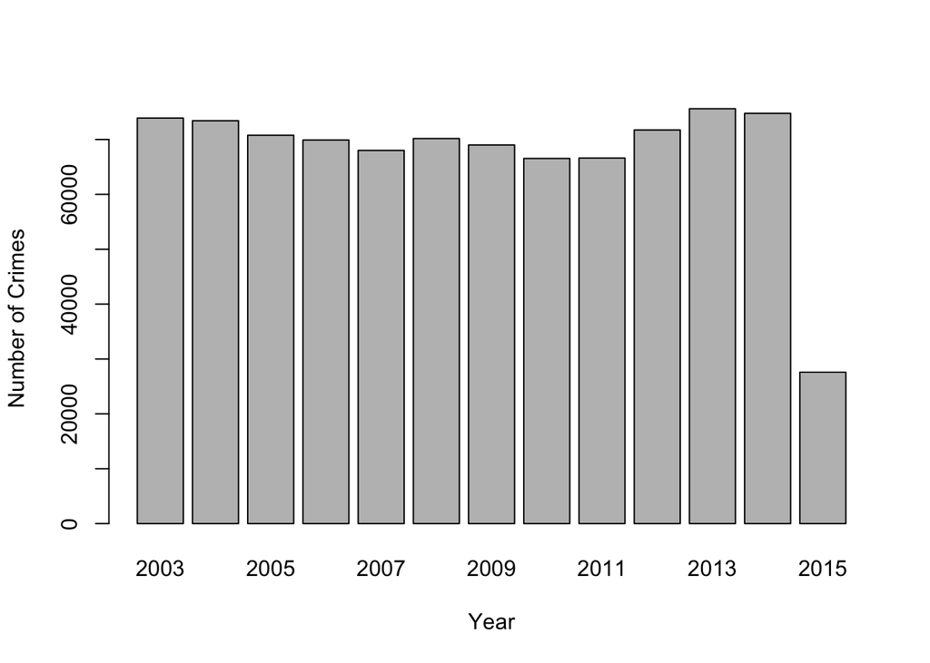

```r
  yeartot <- data.frame(table(traindf$year))
  colnames(yeartot) <- c("year","count")
  barplot(yeartot$count, xlab = "Year", ylab = "Number of Crimes", names.arg = yeartot$year)
```

There is a downward trend from 2003-2011, and then the number of crimes picks up to reach around 2003 levels. Note that only the first five months of data from 2015 are included. This explains the siginficantly small bar corresponding to 2015.

```r
  ## Periodogram on monthly counts of evts divided by category

  monthtot <- subset(traindf[,c("dates","category","monthnum","year")],traindf$year != 2015 )

  categmonthtot <- tapply(monthtot$monthnum, list(monthtot$category, monthtot$monthnum,
                                                  monthtot$year), function(x) length(x))
  categmonthtot <- melt(categmonthtot)
  categmonthtot$value[is.na(categmonthtot$value)] <- 0
  names(categmonthtot) <- c("category","monthnum","year","numevt")
```

Let’s take a look at the monthly counts in all crimes over the time period (2003-2014)

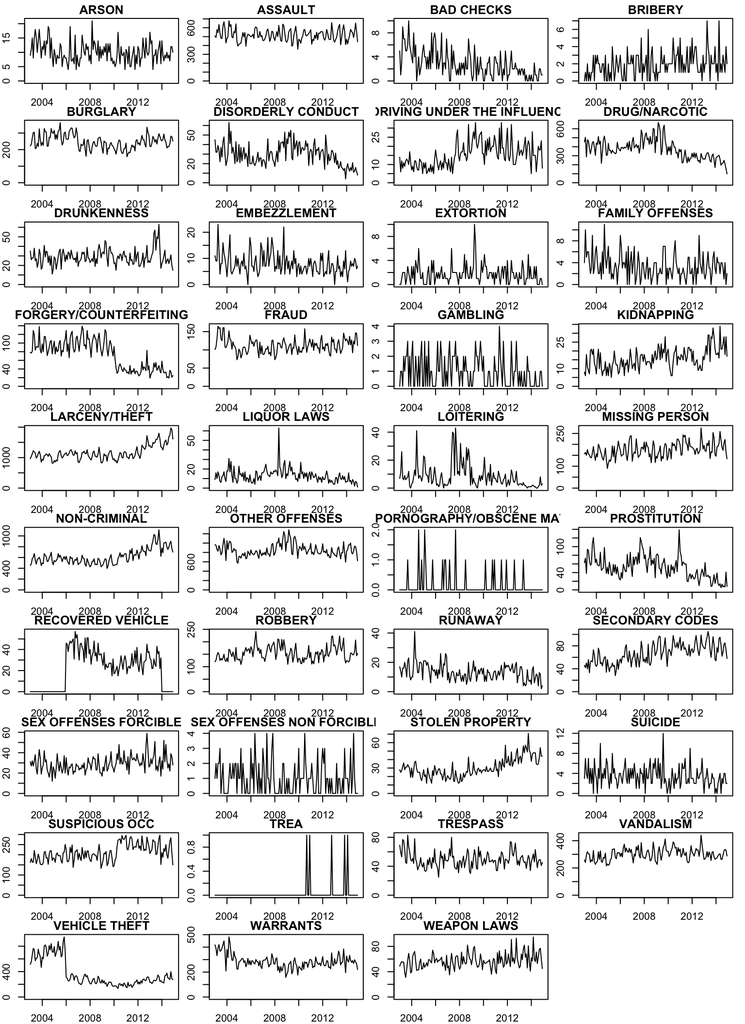

```r
  categvec <- as.character(unique(categmonthtot$category))
  par(mfrow = c(10,4), mar = c(1.5,1.5,1.5,1),oma = c(0.5,0.5,0,0))

  for(i in 1:39){ tmp.ts <- ts(subset(categmonthtot$numevt, categmonthtot$category == categvec[i]),frequency = 12, start = c(2003,1)); plot.ts(tmp.ts,ylim = c(0,max(tmp.ts)),main = categvec[i])}
```

One interesting feature in some plots are level changes. For example, there is a clear dip in forgery/counterfeiting around 2010. The same feature is seen in “VEHICLE THEFT” around 2006. We could speculate that it could be related to some change in book-keeping because we see an opposite level change (though of smaller magnitude) in “RECOVERED VEHICLE”. There also seems to be a level increase in “DRIVING UNDER THE INFLUENCE” at the start of 2008.

Another interesting feature are isolated peaks. The best example (and perhaps only!) of this seems to be the spike a little after 2008 in “LIQUOR LAWS”. It seems unlikely that this peak is just an upward fluctuation.

Potentially, there might be seasonal features. These are probably hard to pick out from the above plot. We can use smoothed periodograms to conduct a spectral analysis of the data.

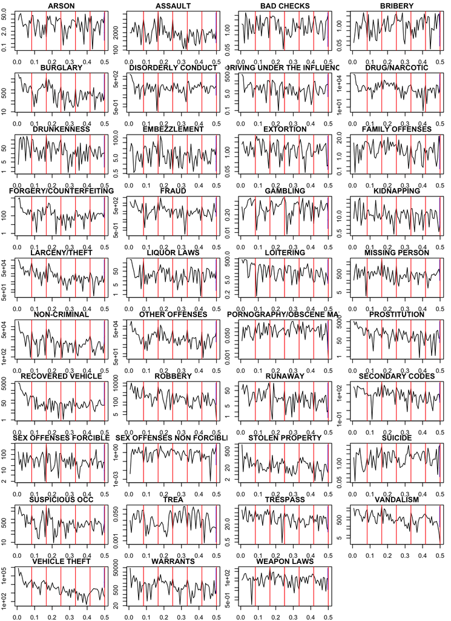

```r
  par(mfrow = c(10,4), mar = c(1.5,1.5,1.5,1),oma = c(0.5,0.5,0,0))
  for(i in 1:39){spec.pgram(subset(categmonthtot$numevt, categmonthtot$category == categvec[i], detrend = T, demean = T), main = categvec[i]); abline(v = c(1/12.,2/12.,3/12.,4/12.,5/12.,6/12.), col = "red")}
```